# NLP Tweets - Trump vs Clint

## 1. Reading Data

> The first step in any machine learning task is concerned with reading in the data. In order to understand how to read in the data, I took a look at how it is stored and the tweets are stored in a comma-separated (csv) file.

```python
import pandas as pd
```

```python
# Reading the data as follows:
header = ['id', 'handle', 'text', 'is_retweet', 'original_author', 'time', 'in_reply_to_screen_name',
          'in_reply_to_status_id', 'in_reply_to_user_id', 'is_quote_status', 'lang', 'retweet_count',
          'favorite_count', 'longitude', 'latitude', 'place_id', 'place_full_name', 'place_name', 'place_type',
          'place_country_code', 'place_country', 'place_contained_within', 'place_attributes', 'place_bounding_box',
          'source_url', 'truncated', 'entities', 'extended_entities']
df = pd.read_csv('tweets.csv', sep=',', skiprows=1, names=header)
```

> Most of the columns in this file contain meta-information such as time stamps, number of retweets, favourites, etc. The `skiprows` argument is used to skip the first row in the file because it is header information.

```python
# Using unique() to remove duplicates
ids = df.id.unique()
n_ids = ids.shape[0]
politicians = df.handle.unique()
n_politicians = politicians.shape[0]
tweets = df.text.unique()
n_tweets = tweets.shape[0]
print ('Number of politicians = ' + str(n_politicians)
       + '\n' + 'Who: ' + str(politicians)
       + '\n' + 'Overall number of tweets = ' + str(n_ids)
       + '\n' + 'Number of unique tweets = ' + str(n_tweets))
```

```
Number of politicians = 2
Who: ['HillaryClinton' 'realDonaldTrump']
Overall number of tweets = 6444
Number of unique tweets = 6434
```

## 2. Data Preprocessing

> These will be my initial steps:
> - Converting strings to lowercase
> - Split strings of text into separate words
> - Lemmatise words

*Importing NLTK, word tokenizer and word lemmatizer:*

```python
import nltk
from nltk import word_tokenize, WordNetLemmatizer
from nltk.tokenize import RegexpTokenizer
```

*Preprocessing textual data with preprocess method:*

```python
def preprocess(sentence):
    lemmatizer = WordNetLemmatizer()
    tokenizer = RegexpTokenizer(r'\w+')
    return [lemmatizer.lemmatize(word.lower()) for word in tokenizer.tokenize(unicode(sentence, errors='ignore'))
            if not word.startswith('/')]
```

> Note that filtering out the words starting with "/" is a straightforward solution for excluding the urls from the set of words (these are frequently included in tweets, but most probably will not provide particular useful information for any future analysis).

*Defining a method to extract the text of each tweet and store it to each candidate:*

```python
def extract(politician_name):
    tweet_texts = []
    for i in range(0, n_ids):
        author = df.handle[i]
        tweet = df.text[i]
        if author==politician_name:
            tweet_texts.append(tweet.strip())
    return tweet_texts
```

*Extracting tweets from Trump and Clint and storing them as different lists:*

```python
# Exploring text:
trump = extract('realDonaldTrump')
clint = extract('HillaryClinton')
print 'Number of Clint tweets:', len(clint)
print 'Number of Trump tweets:', len(trump)
# Example of trump text:
for text in trump:
    print '\nTrump Original Text: ', text
    print 'Trump Preprocessed Text: ', preprocess(text)
```

[output not shown]

[output cut: 10444 more lines]

```

Trump Original Text:  "@lilredfrmkokomo: @realDonaldTrump My Facebook Groups are all voting TRUMP /4000 people! !!" Great!
Trump Preprocessed Text:  [u'lilredfrmkokomo', u'realdonaldtrump', u'my', u'facebook', u'group', u'are', u'all', u'voting', u'trump', u'4000', u'people', u'great']

Trump Original Text:  "@marybnall01: @realDonaldTrump watched lowell mass speech. Awesome. Great crowd. Make America Great Again!!!!!!"
Trump Preprocessed Text:  [u'marybnall01', u'realdonaldtrump', u'watched', u'lowell', u'mass', u'speech', u'awesome', u'great', u'crowd', u'make', u'america', u'great', u'again']

Trump Original Text:  "@ghosthunter_lol: Iowa key endorsement for @realDonaldTrump Can't wait for the Iowa caucus in 4 weeks! #Trump2016 https://t.co/JBfyFrZfFb"
Trump Preprocessed Text:  [u'ghosthunter_lol', u'iowa', u'key', u'endorsement', u'for', u'realdonaldtrump', u'can', u't', u'wait', u'for', u'the', u'iowa', u'caucus', u'in', u'4', u'week', u'trump2016', u'http', u't', u'co', u'jbfyfrzffb']

Trump Original Text:  "@iLoveiDevices: @EdwinRo47796972 @happyjack225 @FoxNews @krauthammer  Minimizing dependency on China is crucial.Only Trump talks about that
Trump Preprocessed Text:  [u'iloveidevices', u'edwinro47796972', u'happyjack225', u'foxnews', u'krauthammer', u'minimizing', u'dependency', u'on', u'china', u'is', u'crucial', u'only', u'trump', u'talk', u'about', u'that']

Trump Original Text:  "@SalRiccobono: @realDonaldTrump @troyconway Donald get big business back and# MAKE AMERICA GREAT AGAIN FOR 2016"
Trump Preprocessed Text:  [u'salriccobono', u'realdonaldtrump', u'troyconway', u'donald', u'get', u'big', u'business', u'back', u'and', u'make', u'america', u'great', u'again', u'for', u'2016']
```

> The dataset is quite balanced between the two candidates. Trump contains 3218 tweets and Clint has 3226 tweets.

## 3. Data Inspection/Understanding

*Saving the different tweets in different lists:*

```python
trump = extract('realDonaldTrump')
clinton = extract('HillaryClinton')
```

*Importing libraris Text and FreqDist from nltk:*

```python
from nltk.text import Text
from nltk import FreqDist
```

*Creating the `context_search` method to search for specific words and their contexts in the tweets:*

```python
def context_search(a_list, search_word):
    for tweet in a_list:
        word_list = preprocess(tweet)
        text_list = Text(word_list)
        search_word = search_word.lower()
        if search_word in word_list:
            text_list.concordance(search_word)
```

*Exploring the use of the word 'America' by both Trump and Clinton:*

```python
context_search(clinton, 'America')
```

```
Displaying 1 of 1 matches:
                             across america agree shewon http t co odiuhd0exo
Displaying 1 of 1 matches:
                                    america ha to live in poverty http t co mpg
Displaying 1 of 1 matches:
                                    america s interestsbut they re great for hi
Displaying 1 of 1 matches:
l win when everyone get to share in america s promise
Displaying 1 of 1 matches:
                                    america every person no matter what you loo
Displaying 1 of 1 matches:
                                    america should have to forgo a higher educa
Displaying 1 of 1 matches:
                                    america ha never made progress by thinking
Displaying 2 of 2 matches:
                                    america is better than this america is bett
message america is better than this america is better than donald trump
Displaying 1 of 1 matches:
                                    america he is lying http t co lje3lkrzqy ht
Displaying 1 of 1 matches:
sked me whether or not i wa born in america nobody ever asked me that
Displaying 1 of 1 matches:
                                    america plain and simple donald trump owes
Displaying 1 of 1 matches:
                                    america and this man want to be our preside
Displaying 1 of 1 matches:
                                    america is one nation under god indivisible
Displaying 1 of 1 matches:
                                    america http t co dkg7pwinmt
Displaying 1 of 1 matches:
                                    america all wrong there nothing we cant do
Displaying 1 of 1 matches:
                                    america i believe in beautiful multifaceted
Displaying 1 of 1 matches:
                                    america s security over his own financial i
Displaying 1 of 1 matches:
                                    america s security and his own bank account
Displaying 1 of 1 matches:
                                    america is not about yes he will it s about
Displaying 1 of 1 matches:
```

[output cut: 345 more lines]

```
                                    america be that great strong land of love t
Displaying 1 of 1 matches:
                                    america s gun violence epidemic is out of c
Displaying 1 of 1 matches:
                                    america deserves clean air to breathe clean
Displaying 1 of 1 matches:
                                    america earthday http t co k7egd4g4dk
Displaying 1 of 1 matches:
wable energy to power every home in america
Displaying 1 of 1 matches:
                                    america that s divisive amp dangerous we sh
Displaying 1 of 1 matches:
r worship the sameand that s one of america s biggest strength http t co m4cj0n
Displaying 1 of 1 matches:
                                    america home live in fear of being torn apa
```

```python
context_search(trump, 'America')
```

```
Displaying 1 of 1 matches:
                                    america center in council bluff iowa ticket
Displaying 1 of 1 matches:
 day and were still going thank you america maga
Displaying 1 of 1 matches:
                                    america safe amp great again http t co 39fc
Displaying 1 of 1 matches:
                                    america safe and great again with the ameri
Displaying 1 of 1 matches:
                                    america le safe that s why 200 general and
Displaying 1 of 1 matches:
                                    america will become the world s great magne
Displaying 1 of 1 matches:
nd vote on november 8 2016 let make america safe http t co mqdp4gglie
Displaying 1 of 1 matches:
                            to make america safe again
Displaying 1 of 1 matches:
                                    america saf http t co lt2l3nkzyi
Displaying 1 of 1 matches:
              together we will make america safe and great again imwithyou amer
Displaying 1 of 1 matches:
                                    america will become the world s great magne
Displaying 1 of 1 matches:
                                    america lesm maga http t co mcbc2jzhn2 http
Displaying 1 of 1 matches:
                                    america great again join u http t co 3kwol2
Displaying 1 of 1 matches:
                                    america great again transcript http t co rn
Displaying 1 of 1 matches:
                                    america great again join u http t co 3kwol2
Displaying 1 of 1 matches:
                               make america great again http t co 3kwol20zmm ht
Displaying 1 of 1 matches:
                               make america great again americafirst imwithyou
Displaying 1 of 1 matches:
                          thank you america great commanderinchiefforum poll ht
Displaying 1 of 1 matches:
                                    america before too late
Displaying 1 of 1 matches:
                                    america we re going to create a new america
```

[output cut: 372 more lines]

```
ceofspadeshq this election is about america future vote trump
Displaying 1 of 1 matches:
 focused on her yet on our way make america great again
Displaying 1 of 1 matches:
                                    america great again for my kid thank you
Displaying 1 of 1 matches:
                                    america great again is unbelievable http t
Displaying 1 of 1 matches:
                                    america great again
Displaying 1 of 1 matches:
                      to recuperate america
Displaying 1 of 1 matches:
ass speech awesome great crowd make america great again
Displaying 1 of 1 matches:
             business back and make america great again for 2016
```

*Checking for frequency of selected words 'america' and 'russia' and 'gun':*

```python
def search_word_freq (a_list, word):
    word_list = []
    for tweet in a_list:
        word_list += preprocess(tweet)
    text_list = Text(word_list)
    fdist = FreqDist(text_list)
    print ("Frequent of '%s' Word Search: ") %word + str(fdist[word])

print "Trump:"
search_word_freq(trump,'america')
search_word_freq(trump,'russia')
search_word_freq(trump,'gun')
print "Clint:"
search_word_freq(clint, 'america')
search_word_freq(clint, 'russia')
search_word_freq(clint, 'gun')
```

```
Trump:
Frequent of 'america' Word Search: 217
Frequent of 'russia' Word Search: 13
Frequent of 'gun' Word Search: 13
Clint:
Frequent of 'america' Word Search: 209
Frequent of 'russia' Word Search: 9
Frequent of 'gun' Word Search: 64
```

*Checking the vocabulary for each candidate:*

```python
def vocabulary(a_list):
    vocab = []
    for tweet in a_list:
        text_list = preprocess(tweet)
        vocab = vocab + text_list
    return sorted(set(vocab))

trump_vocab = vocabulary(trump)
clinton_vocab = vocabulary(clinton)
print ("Trump's vocabulary size: ") + str(len(trump_vocab))
print ("Clinton's vocabulary size: " + str(len(clinton_vocab)))
```

```
Trump's vocabulary size: 7080
Clinton's vocabulary size: 8082
```

*Checking how diverse and lexically rich is the language of both candidates:*

```python
def word_count(a_list):
    total_length = 0
    unique_words = []
    for tweet in a_list:
        text_list = preprocess(tweet)
        total_length = total_length + len(text_list)
        unique_words = unique_words + text_list
    print ("Total length " + str(total_length))
    print ("Unique words " + str(len(set(unique_words))))
    print ("Lexical richness " + str(100 * round(float(len(set(unique_words)))/float(total_length), 4)) + "%")

print '\nTrump:'
word_count(trump)
print '\nClinton:'
word_count(clinton)
```

```
Trump:
Total length 60674
Unique words 7080
Lexical richness 11.67%

Clinton:
Total length 65546
Unique words 8082
Lexical richness 12.33%
```

*Extracting stopwords, punctuation, filtering words and ploting frequent words:*

```
Trump:
[(u'http', 1515), (u'thank', 522), (u'great', 465), (u'trump', 393), (u'hillary', 363), (u'trump2016', 349), (u'realdonaldtrump', 332), (u'amp', 268), (u'makeamericagreatagain', 255), (u'people', 226), (u'america', 217), (u'clinton', 215), (u'cruz', 203), (u'new', 190), (u'crooked', 186), (u'make', …
```

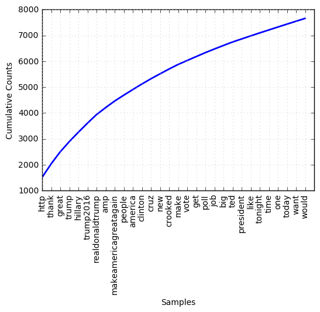

```
Clint:
[(u'http', 2504), (u'trump', 932), (u'hillary', 760), (u'donald', 425), (u'president', 275), (u'american', 228), (u'make', 211), (u'america', 209), (u'people', 198), (u'woman', 195), (u'let', 189), (u'family', 189), (u'one', 183), (u'need', 153), (u'potus', 146), (u'right', 133), (u'get', 131), (u'c…
```

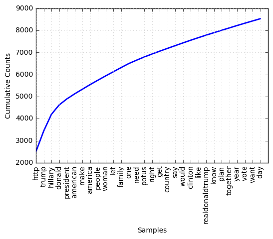

```python
from nltk.corpus import stopwords
import re
import string

stoplist = stopwords.words('english')

def filtered_words(a_list):
    word_list = []
    for tweet in a_list:
        word_list += preprocess(tweet) # preprocessing tweets
    text_list = Text(word_list)
    text_with_no_stopwords = [] # removing stopwords
    for word in text_list:
        if word not in stoplist:
            text_with_no_stopwords.append(word)
    return [w for w in text_with_no_stopwords if len(w)>2 and w not in string.punctuation] # removing punctuation

def extract_freq_words (a_list):
    get_freq = filtered_words(a_list)
    fdist = FreqDist(get_freq) # getting frequency
    print(fdist.most_common(30))
    fdist.plot(30, cumulative=True)

print "Trump:"
extract_freq_words(trump)
print "Clint:"
extract_freq_words(clinton)
```

Interesting information when compared with other previous presidents reports from `https://www.cmu.edu/news/stories/archives/2016/march/speechifying.html`.

[figure not shown]

## 4. Supervised Learning: Predicting Tweet Author

Predicting the author of a tweet by using a supervised method: Naive Bayes `(http://scikit-learn.org/stable/)`.

```python
import random
from nltk import NaiveBayesClassifier, classify
```

*Creating features from textual data, words used in tweets:*

```python
stoplist = stopwords.words('english')

def get_features(tweet, setting):
    features = {}
    word_list = preprocess(tweet)
    for word in word_list:
        if word not in stoplist:
            if setting=="bow":
                features[word] = features.get(word, 0) + 1
            else:
                features[word] = True
    return features
```

*Defining a train method and training the classifier Naive Bayes:*

```python
def train(features, n): # n is the size of the training set, the proportion of tweets to use for training, e.g. 80%
    train_size = int(len(features) * n)

    # Creating training and test sets
    train_set, test_set = features[:train_size], features[train_size:]
    print ("Training set size = " + str(len(train_set)) + " tweets")
    print ("Test set size = " + str(len(test_set)) + " tweets")

    # Training the Naive Bayes Classifier
    classifier = NaiveBayesClassifier.train(train_set)
    return train_set, test_set, classifier
```

*Extracting features and training the classifier:*

```python
# Getting the tweets
all_tweets = [(tweet, "trump") for tweet in trump]
all_tweets += [(tweet, "clinton") for tweet in clinton]
random.shuffle(all_tweets) # shuffling the data for a better randomness
print ("Dataset Size = " + str(len(all_tweets)) + " tweets")

# Extract the textual features
all_features = [(get_features(tweet, ""), label) for (tweet, label) in all_tweets]
print ("Collected = " + str(len(all_features)) + " features")

# Train the classifier with a 80:20 split
train_set, test_set, classifier = train(all_features, 0.8)
```

```
Dataset Size = 6444 tweets
Collected = 6444 features
Training set size = 5155 tweets
Test set size = 1289 tweets
```

*Evaluating the accuracy of the classifier and extracting the most predictive features/most informative words:*

```python
def evaluate(train_set, test_set, classifier):
    print ("Traning Set Accuracy = " + str(classify.accuracy(classifier, train_set)))
    print ("Test Set Accuracy = " + str(classify.accuracy(classifier, test_set)))
    # checking which words are most informative for the classifier – randomly selected 50 most informative
    classifier.show_most_informative_features(50)

# evaluating classifier's performance
evaluate(train_set, test_set, classifier)
```

```
Traning Set Accuracy = 0.982541222114
Test Set Accuracy = 0.937160589604
Most Informative Features
                   rubio = True            trump : clinto =     44.8 : 1.0
                  medium = True            trump : clinto =     42.9 : 1.0
                      de = True           clinto : trump  =     34.5 : 1.0
                   crowd = True            trump : clinto =     33.5 : 1.0
                    cruz = True            trump : clinto =     29.4 : 1.0
                   enjoy = True            trump : clinto =     28.1 : 1.0
            demsinphilly = True           clinto : trump  =     27.8 : 1.0
                    lgbt = True           clinto : trump  =     26.4 : 1.0
                   marco = True            trump : clinto =     24.9 : 1.0
                   south = True            trump : clinto =     24.2 : 1.0
                     cnn = True            trump : clinto =     24.1 : 1.0
                   total = True            trump : clinto =     23.6 : 1.0
                 deserve = True           clinto : trump  =     21.7 : 1.0
                  border = True            trump : clinto =     21.6 : 1.0
                  nevada = True            trump : clinto =     17.6 : 1.0
                 amazing = True            trump : clinto =     17.5 : 1.0
                     ted = True            trump : clinto =     16.5 : 1.0
           berniesanders = True           clinto : trump  =     16.4 : 1.0
                    weak = True            trump : clinto =     16.3 : 1.0
                   phony = True            trump : clinto =     16.3 : 1.0
                    bush = True            trump : clinto =     15.6 : 1.0
               wisconsin = True            trump : clinto =     15.6 : 1.0
                  health = True           clinto : trump  =     15.1 : 1.0
                    nice = True            trump : clinto =     14.5 : 1.0
                   thats = True           clinto : trump  =     14.4 : 1.0
                    chip = True           clinto : trump  =     13.7 : 1.0
                   false = True            trump : clinto =     13.6 : 1.0
                    poll = True            trump : clinto =     13.5 : 1.0
               elizabeth = True            trump : clinto =     13.0 : 1.0
                stronger = True           clinto : trump  =     12.6 : 1.0
                 imagine = True           clinto : trump  =     12.4 : 1.0
                 tuesday = True            trump : clinto =     12.3 : 1.0
                   email = True            trump : clinto =     12.3 : 1.0
                violence = True           clinto : trump  =     12.2 : 1.0
               hampshire = True            trump : clinto =     11.8 : 1.0
                     mom = True           clinto : trump  =     11.7 : 1.0
                    fear = True           clinto : trump  =     11.7 : 1.0
                  muslim = True           clinto : trump  =     11.4 : 1.0
                   thank = True            trump : clinto =     11.4 : 1.0
                   trail = True           clinto : trump  =     11.0 : 1.0
                   video = True            trump : clinto =     10.7 : 1.0
            pennsylvania = True            trump : clinto =     10.6 : 1.0
                 radical = True            trump : clinto =     10.3 : 1.0
                 florida = True            trump : clinto =     10.3 : 1.0
                carolina = True            trump : clinto =     10.1 : 1.0
                     cut = True           clinto : trump  =      9.8 : 1.0
                 illegal = True            trump : clinto =      9.8 : 1.0
                  easier = True           clinto : trump  =      9.7 : 1.0
                 student = True           clinto : trump  =      9.6 : 1.0
                       h = True           clinto : trump  =      9.5 : 1.0
```

Depending on the random split and the random shuffle before splitting we can expect around 98% accuracy on the training and 92-94% on the test data.

*Evaluating the performance of the classifier on each of the two classes separately:*

Spliting the test set into *trump* and *clinton* subsets and calculating each subset accuracy separately.

```python
def train_class (features, n, label): # n is the proportion of tweets to use for training; label is the candidate
    train_size = int(len(features) * n)

    # Initialise Training and Test sets
    train_set = features[:train_size]
    test_set = []
    for feature in features[train_size:]:
        if feature[1]==label:
            test_set.append(feature)
    print ("Training Size = " + str(len(train_set)) + " tweets")
    print ("Test Size = " + str(len(test_set)) + " tweets")

    # Train the Naive Bayes Classifier
    classifier = NaiveBayesClassifier.train(train_set)
    return train_set, test_set, classifier
```

*Testing and evaluating the classifier for each class:*

```python
# Getting the tweets
all_tweets = [(tweet, "trump") for tweet in trump]
all_tweets += [(tweet, "clinton") for tweet in clinton]
random.shuffle(all_tweets)
print ("Dataset size = " + str(len(all_tweets)) + " tweets")

# Extracting the textual features
all_features = [(get_features(tweet, ""), label) for (tweet, label) in all_tweets]
print ("Collected " + str(len(all_features)) + " features")

# Training Classifier with 80% and Test on "trump"
print ("\nAccuracy on tweets from Trump:")
train_set, test_set, classifier = train_class(all_features, 0.8, "trump")
evaluate(train_set, test_set, classifier)
# Training Classifier with 80% and Test on "clinton"
print ("\nAccuracy on tweets from Clinton:")
train_set, test_set, classifier = train_class(all_features, 0.8, "clinton")
evaluate(train_set, test_set, classifier)
```

```
Dataset size = 6444 tweets
Collected 6444 features

Accuracy on tweets from Trump:
Training Size = 5155 tweets
Test Size = 652 tweets
Traning Set Accuracy = 0.981959262852
Test Set Accuracy = 0.914110429448
Most Informative Features
                   rubio = True            trump : clinto =     46.1 : 1.0
                    cruz = True            trump : clinto =     45.1 : 1.0
                    iowa = True            trump : clinto =     44.7 : 1.0
                  medium = True            trump : clinto =     44.1 : 1.0
                     wow = True            trump : clinto =     36.7 : 1.0
                     cnn = True            trump : clinto =     33.7 : 1.0
                   enjoy = True            trump : clinto =     33.3 : 1.0
                      de = True           clinto : trump  =     31.4 : 1.0
                    lgbt = True           clinto : trump  =     25.4 : 1.0
                   marco = True            trump : clinto =     24.6 : 1.0
                 deserve = True           clinto : trump  =     23.5 : 1.0
                 college = True           clinto : trump  =     23.5 : 1.0
                   crowd = True            trump : clinto =     22.4 : 1.0
                     ted = True            trump : clinto =     22.1 : 1.0
                  border = True            trump : clinto =     21.9 : 1.0
                  muslim = True           clinto : trump  =     17.5 : 1.0
                   phony = True            trump : clinto =     16.5 : 1.0
                  nevada = True            trump : clinto =     16.5 : 1.0
               wisconsin = True            trump : clinto =     15.8 : 1.0
                stronger = True           clinto : trump  =     15.3 : 1.0
               elizabeth = True            trump : clinto =     15.1 : 1.0
                   south = True            trump : clinto =     15.1 : 1.0
                    chip = True           clinto : trump  =     14.9 : 1.0
                    poll = True            trump : clinto =     14.7 : 1.0
               hampshire = True            trump : clinto =     14.7 : 1.0
                 amazing = True            trump : clinto =     14.6 : 1.0
                    bush = True            trump : clinto =     14.5 : 1.0
                  report = True            trump : clinto =     14.5 : 1.0
                  bernie = True            trump : clinto =     14.0 : 1.0
                   false = True            trump : clinto =     13.8 : 1.0
                   thats = True           clinto : trump  =     13.5 : 1.0
```

[output cut: 61 more lines]

```
                 imagine = True           clinto : trump  =     12.2 : 1.0
                carolina = True            trump : clinto =     12.0 : 1.0
                negative = True            trump : clinto =     11.8 : 1.0
                  paying = True           clinto : trump  =     11.6 : 1.0
                progress = True           clinto : trump  =     11.6 : 1.0
                   thank = True            trump : clinto =     11.5 : 1.0
                  health = True           clinto : trump  =     11.2 : 1.0
               fantastic = True            trump : clinto =     11.1 : 1.0
                   black = True           clinto : trump  =     10.5 : 1.0
                  profit = True           clinto : trump  =     10.2 : 1.0
               wonderful = True            trump : clinto =     10.2 : 1.0
                 student = True           clinto : trump  =      9.8 : 1.0
                   truly = True            trump : clinto =      9.8 : 1.0
                  caucus = True            trump : clinto =      9.8 : 1.0
                colorado = True            trump : clinto =      9.8 : 1.0
```

**Clint:**

- Training Accuracy: ~ 98.2%
- Test Accuracy: ~ 95.7%

Depending on the data random split selected these results will change.

## 5. Unsupervised Learning: Predicting Tweet Author

Now will use a Unsupervised Method KMeans clustering `(http://scikit-learn.org/stable/)`.

```python
import numpy as np
from sklearn.decomposition import TruncatedSVD
from sklearn.feature_extraction.text import TfidfVectorizer, TfidfTransformer
from sklearn.pipeline import make_pipeline
from sklearn.preprocessing import Normalizer
from sklearn.cluster import KMeans
from sklearn import metrics
```

*Initializing the data by storing the tweets in `data` data-structure and candidates names in the list of `labels`. Casting the strings* trump *and* clinton *to numerical values, for example, 0 and 1:*

```python
def init_clust_data():
    all_tweets = [(tweet, "trump") for tweet in trump]
    all_tweets += [(tweet, "clinton") for tweet in clinton]
    random.shuffle(all_tweets)
    data = []
    labels = []
    for entry in all_tweets:
        data.append(entry[0])
        if entry[1]=="trump":
            labels.append(0)
        else:
            labels.append(1)

    print("Data:")
    print(str(len(data)) + " tweets in 2 categories\n")
    print(data)

    print("Data labels: ")
    print(labels)
    gs_clusters = len(set(labels))
    print("Gold standard clusters: " + str(gs_clusters))
    return data, labels, gs_clusters


data, labels, gs_clusters = init_clust_data()
```

[output not shown]

*Applying data transformation and dimensionality reduction:*

```python
def transform(orig_data, orig_dim, red_dim):
    vectorizer = TfidfVectorizer(min_df=2, max_df=0.5,
                                 max_features=orig_dim,
                                 stop_words='english',
                                 use_idf=True)
    trans_data = vectorizer.fit_transform(orig_data)

    print("\nData contains: " + str(trans_data.shape[0]) + " with " + str(trans_data.shape[1]) + " features.")

    svd = TruncatedSVD(red_dim)
    normalizer = Normalizer(copy=False)
    lsa = make_pipeline(svd, normalizer)

    return lsa.fit_transform(trans_data), vectorizer, svd

trans_data, vectorizer, svd = transform(data, 10000, 300)
```

```
Data contains: 6444 with 4498 features.
```

*Applying KMeans Clustering Algorithm:*

```python
def cluster(trans_data, gs_clusters):
    km = KMeans(n_clusters=gs_clusters, init='k-means++', max_iter=100, n_init=1)
    km.fit(trans_data)
    return km

km = cluster(trans_data, gs_clusters)
```

*Evaluating the identified clusters against gold standard clusters:*

```python
def evaluate(km, labels, svd):
    print("Clustering report:\n")
    print("* Homogeneity: " + str(metrics.homogeneity_score(labels, km.labels_)))
    print("* Completeness: " + str(metrics.completeness_score(labels, km.labels_)))
    print("* V-measure: " + str(metrics.v_measure_score(labels, km.labels_)))

    print("\nMost discriminative words per cluster:")
    original_space_centroids = svd.inverse_transform(km.cluster_centers_)
    order_centroids = original_space_centroids.argsort()[:, ::-1]

    terms = vectorizer.get_feature_names()
    for i in range(gs_clusters):
        print("Cluster " + str(i) + ": ")
        cl_terms = ""
        for ind in order_centroids[i, :50]:
            cl_terms += terms[ind] + " "
        print(cl_terms + "\n")


evaluate(km, labels, svd)
```

```
Clustering report:

* Homogeneity: 0.0793489253062
* Completeness: 0.164478314243
* V-measure: 0.107052661511

Most discriminative words per cluster:
Cluster 0:
thank trump2016 makeamericagreatagain great new votetrump america americafirst join poll imwithyou support soon amp tomorrow maga florida hampshire carolina iowa supertuesday make california indiana realdonaldtrump arizona pennsylvania york just ohio south today tonight fitn virginia trumppence16 ni…

Cluster 1:
trump hillary realdonaldtrump donald president people great america just clinton make amp let like vote country cruz new women today potus time crooked need american campaign going families don watch big americans tonight good hillaryclinton said want ted ve day know obama win right won years love j…
```

The results suggest that unsupervised approach performs worse than supervised algorithm.

## 6. Language modelling

*Generating the tweets written by Trump and Clinton, using a language model:*

```python
from collections import defaultdict, Counter
from numpy import cumsum, sum, searchsorted
from numpy.random import rand


class LanguageModel(object):
    def __init__(self, order=1):
        '''Initializes a language model of the given order.'''
        self._transitions = defaultdict(int)
        self._order = order

    def train(self, sequence):
        '''Trains the model using sequence.'''
        self._symbols = list(set(sequence))
        for i in range(len(sequence)-self._order):
            self._transitions[sequence[i:i+self._order], sequence[i+self._order]] += 1

    def predict(self, symbol):
        '''Takes as input a string and predicts the next character.'''
        if len(symbol) != self._order:
            raise ValueError('Expected string of %d chars, got %d' % (self._order, len(symbol)))
        probs = [self._transitions[(symbol, s)] for s in self._symbols]
        return self._symbols[self._weighted_pick(probs)]

    def generate(self, start, n):
        '''Generates n characters from start.'''
        result = start
        for i in range(n):
            new = self.predict(start)
            result += new
            start = start[1:] + new
        return result

    @staticmethod
    def _weighted_pick(weights):
        '''Weighted random selection returns n_picks random indexes.
          The chance to pick the index i is given by weights[i].'''
        return searchsorted(cumsum(weights), rand()*sum(weights))
```

*Using the tweets from the dataset to generate new ones. First, let's combine all the tweets from a candidate in one long string of text:*

```python
def all_tweets(a_list):
    candidate_tweet = ""
    for tweet in a_list:
        candidate_tweet += tweet
    return candidate_tweet
```

*Applying `LanguageModel` methods to train on the `candidate_tweet` and to generate new tweets for Donald Trump and Hillary Clinton:*

```python
model = LanguageModel(order=6) #using 6 characters, but this order of the language model can be changed.
print 'Donald Trump:'
model.train(all_tweets(trump))
print model.generate('make a', 140)
print '\nHillary Clint:'
model.train(all_tweets(clinton))
print model.generate('make a', 140)
```

```
Donald Trump:
make a spontaneous reaction -- maybe her candidate (in many promises to ISIS. 200 dead on The Republican primary #MakeAmericaGreatAgain https://t.

Hillary Clint:
make a dog! Ted Cruz #MakeAmerica. https://t.co/Nl1rebbrwnMade all voters to appear on anything her!I have to deflect blame Jeb in the positions.
```